# Recheck the correlation approach for ICC estimation

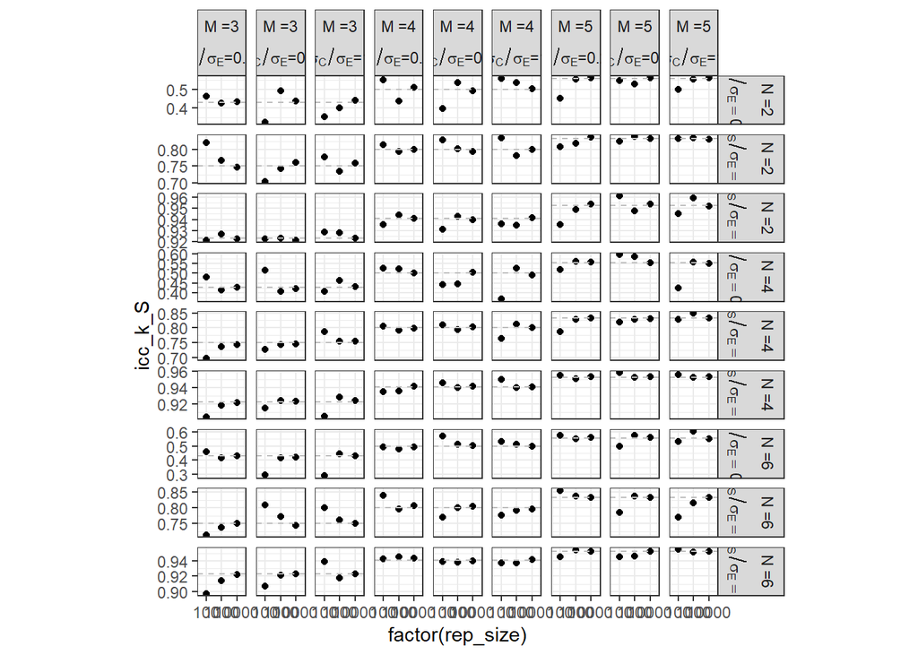

Figure 12: $ ho^{S}(M)$ for Case 4

```r
case4_sim |>
  select(rep_size, N, M, sigma_E, sigma_SE_ratio, sigma_CE_ratio, ICC_k_S, icc_k_S) |>
  ggplot(aes(x = factor(rep_size), y = icc_k_S)) +
  geom_point() +
  geom_hline(aes(yintercept = ICC_k_S), linetype = "dashed", color = "gray") +
  facet_grid(N + sigma_SE_ratio ~ M + sigma_CE_ratio,
             labeller = label_bquote(rows = atop(paste("N =", .(N)),
                                                 paste(sigma[S]/sigma[E] == .(sigma_SE_ratio))),
                                     cols = atop(paste("M =", .(M)),
                                                 paste(sigma[C]/sigma[E], "=", .(sigma_CE_ratio)))),
            scales = "free")
```

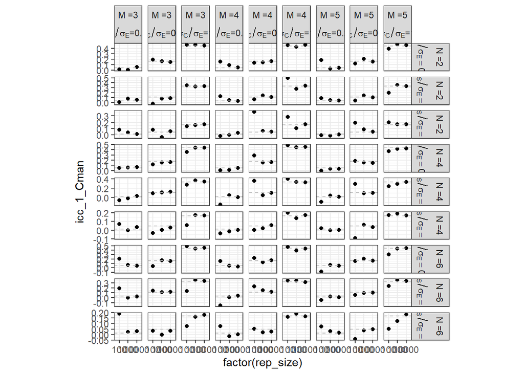

Figure 13: $ ho^{Cman}(1)$ for Case 4

```r
case4_sim |>
  select(rep_size, N, M, sigma_E, sigma_SE_ratio, sigma_CE_ratio, ICC_1_Cman, icc_1_Cman) |>
  ggplot(aes(x = factor(rep_size), y = icc_1_Cman)) +
  geom_point() +
  geom_hline(aes(yintercept = ICC_1_Cman), linetype = "dashed", color = "gray") +
  facet_grid(N + sigma_SE_ratio ~ M + sigma_CE_ratio,
             labeller = label_bquote(rows = atop(paste("N =", .(N)),
                                                 paste(sigma[S]/sigma[E] == .(sigma_SE_ratio))),
                                     cols = atop(paste("M =", .(M)),
                                                 paste(sigma[C]/sigma[E], "=", .(sigma_CE_ratio)))),
            scales = "free")
```

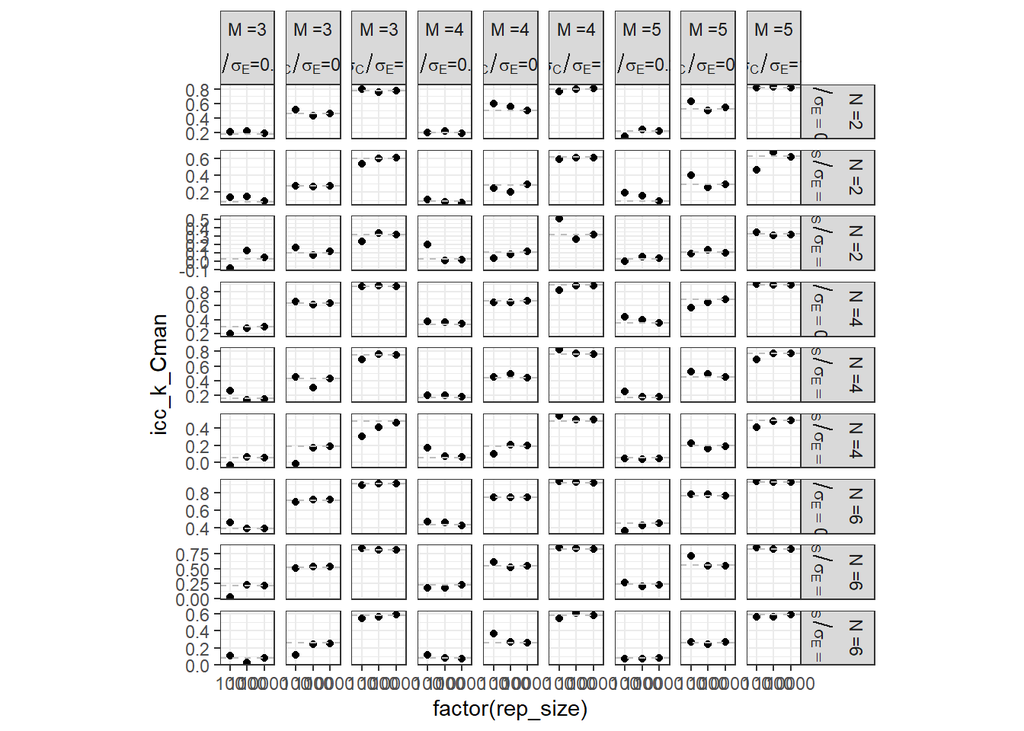

Figure 14: $ ho^{Cman}(N, M)$ for Case 4

```r
case4_sim |>
  select(rep_size, N, M, sigma_E, sigma_SE_ratio, sigma_CE_ratio, ICC_k_Cman, icc_k_Cman) |>
  ggplot(aes(x = factor(rep_size), y = icc_k_Cman)) +
  geom_point() +
  geom_hline(aes(yintercept = ICC_k_Cman), linetype = "dashed", color = "gray") +
  facet_grid(N + sigma_SE_ratio ~ M + sigma_CE_ratio,
             labeller = label_bquote(rows = atop(paste("N =", .(N)),
                                                 paste(sigma[S]/sigma[E] == .(sigma_SE_ratio))),
                                     cols = atop(paste("M =", .(M)),
                                                 paste(sigma[C]/sigma[E], "=", .(sigma_CE_ratio)))),
            scales = "free")
```

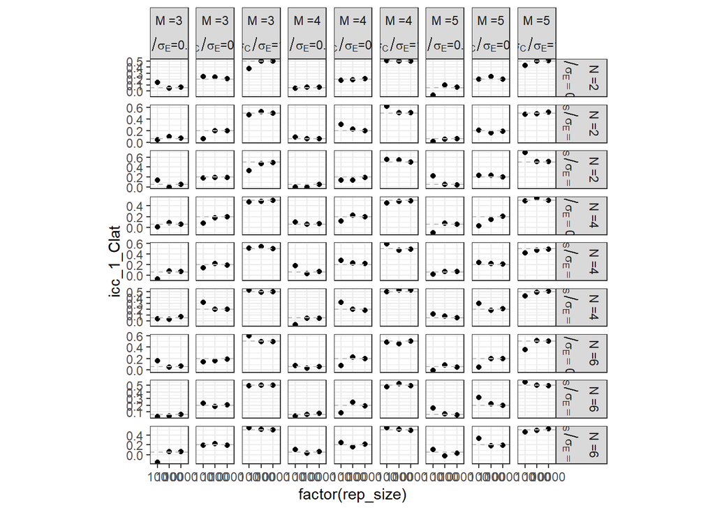

Figure 15: $ ho^{Clat}(1)$ for Case 4

```r
case4_sim |>
  select(rep_size, N, M, sigma_E, sigma_SE_ratio, sigma_CE_ratio, ICC_1_Clat, icc_1_Clat) |>
  ggplot(aes(x = factor(rep_size), y = icc_1_Clat)) +
  geom_point() +
  geom_hline(aes(yintercept = ICC_1_Clat), linetype = "dashed", color = "gray") +
  facet_grid(N + sigma_SE_ratio ~ M + sigma_CE_ratio,
             labeller = label_bquote(rows = atop(paste("N =", .(N)),
                                                 paste(sigma[S]/sigma[E] == .(sigma_SE_ratio))),
                                     cols = atop(paste("M =", .(M)),
                                                 paste(sigma[C]/sigma[E], "=", .(sigma_CE_ratio)))),
            scales = "free")
```

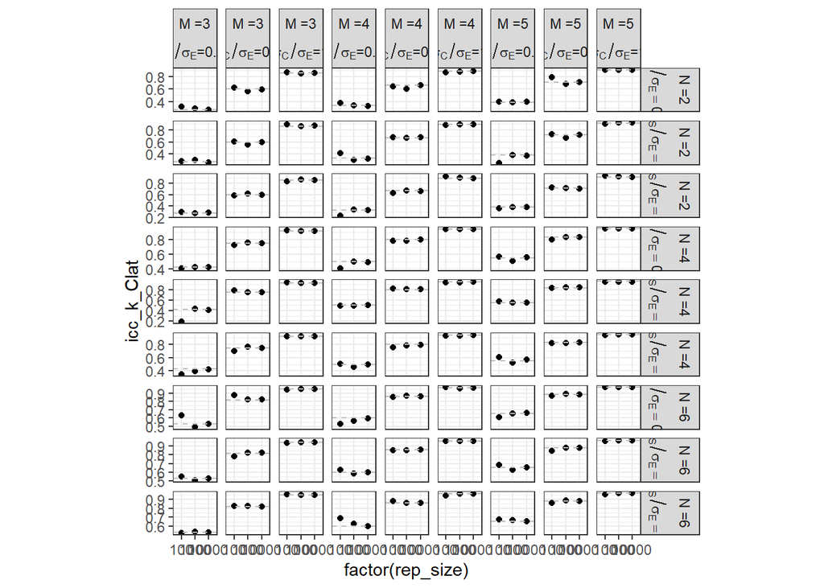

Figure 16: $ ho^{Clat}(N, M)$ for Case 4

```r
case4_sim |>
  select(rep_size, N, M, sigma_E, sigma_SE_ratio, sigma_CE_ratio, ICC_k_Clat, icc_k_Clat) |>
  ggplot(aes(x = factor(rep_size), y = icc_k_Clat)) +
  geom_point() +
  geom_hline(aes(yintercept = ICC_k_Clat), linetype = "dashed", color = "gray") +
  facet_grid(N + sigma_SE_ratio ~ M + sigma_CE_ratio,
             labeller = label_bquote(rows = atop(paste("N =", .(N)),
                                                 paste(sigma[S]/sigma[E] == .(sigma_SE_ratio))),
                                     cols = atop(paste("M =", .(M)),
                                                 paste(sigma[C]/sigma[E], "=", .(sigma_CE_ratio)))),
            scales = "free")
```

## 2.5 Case 5: Person(Cluster) x Rater ANOVA Design

Subject: $i = 1, \dots, N$, Raters: $j = 1, \dots, M$ and Clusters: $k = 1, \dots, O$. Subjects are nested within clusters, and raters are crossed with subjects and cluster.

$$Y_{i(k)j} = \mu + C_k + S(C)_{i(k)} + R_j + (C \times R)_{kj} + E_{i(k)j}$$

where

- $C_k \sim N(0, \sigma_C^2)$
- $S(C)_{i(k)} \sim N(0, \sigma_S^2)$
- $R_j \sim N(0, \sigma_R^2)$
- $(C \times R)_{kj} \sim N(0, \sigma_{CR}^2)$
- $E_{i(k)j} \sim N(0, \sigma_E^2)$

There are up to 12 ICCs in this design …

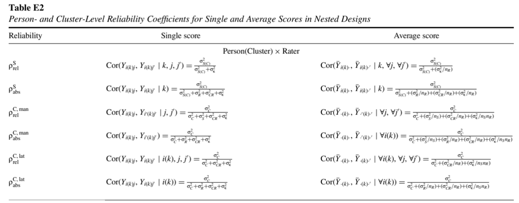

**Simply check the ICC calculations**

```r
# settings
N <- 4
M <- 3
sigma_C <- 2
sigma_S <- 3
sigma_R <- 4
sigma_CR <- 1.5
sigma_E <- 5

pars_case5 = list(mu = 2, sigma_C = sigma_C, sigma_S = sigma_S, sigma_R = sigma_R, sigma_CR = sigma_CR, sigma_E = sigma_E, N = N, M = M)

# results
case5_table <- tibble(
  Reliability = c("$\\rho_{abs}^{S}(1)$", "$\\rho_{abs}^{S}(M)$", "$\\rho_{rel}^{S}(1)$", "$\\rho_{rel}^{S}(M)$", "$\\rho_{abs}^{Cman}(1, 1)$", "$\\rho_{abs}^{Cman}(N, M)$", "$\\rho_{rel}^{Cman}(1, 1)$", "$\\rho_{rel}^{Cman}(N, M)$", "$\\rho_{abs}^{Clat}(1,1)$", "$\\rho_{abs}^{Clat}(N, M)$", "$\\rho_{rel}^{Clat}(1,1)$", "$\\rho_{rel}^{Clat}(N, M)$"),
  Setting = c(
    sigma_S^2 / (sigma_S^2 + sigma_R^2 + sigma_CR^2 + sigma_E^2),
    sigma_S^2 / (sigma_S^2 + sigma_R^2 / M + sigma_CR^2 / M + sigma_E^2 / M),
    sigma_S^2 / (sigma_S^2 + sigma_E^2),
    sigma_S^2 / (sigma_S^2 + sigma_E^2 / M),
    sigma_C^2 / (sigma_C^2 + sigma_S^2 + sigma_R^2 + sigma_CR^2 + sigma_E^2),
    sigma_C^2 / (sigma_C^2 + sigma_S^2 / N + sigma_R^2 / M + sigma_CR^2 / M + sigma_E^2 / (N * M)),
    sigma_C^2 / (sigma_C^2 + sigma_S^2 + sigma_CR^2 + sigma_E^2),
    sigma_C^2 / (sigma_C^2 + sigma_S^2 / N + sigma_CR^2 / M + sigma_E^2 / (N * M)),
    sigma_C^2 / (sigma_C^2 + sigma_R^2 + sigma_CR^2 + sigma_E^2),
    sigma_C^2 / (sigma_C^2 + sigma_R^2 / M + sigma_CR^2 / M + sigma_E^2 / (N * M)),
    sigma_C^2 / (sigma_C^2 + sigma_CR^2 + sigma_E^2),
    sigma_C^2 / (sigma_C^2 + sigma_CR^2 / M + sigma_E^2 / (N * M))
  ),
  Simulation = c(
    icc_cor(pars = pars_case5, model = "threeway-nestcrossed", type = "agreement", unit = "single", level = "subject", rep_size = 100000),
    icc_cor(pars = pars_case5, model = "threeway-nestcrossed", type = "agreement", unit = "average", level = "subject", rep_size = 100000),
    icc_cor(pars = pars_case5, model = "threeway-nestcrossed", type = "consistency", unit = "single", level = "subject", rep_size = 100000),
    icc_cor(pars = pars_case5, model = "threeway-nestcrossed", type = "consistency", unit = "average", level = "subject", rep_size = 100000),
    icc_cor(pars = pars_case5, model = "threeway-nestcrossed", type = "agreement", unit = "single", level = "cluster", clus_score_form = "manifest", rep_size = 100000),
    icc_cor(pars = pars_case5, model = "threeway-nestcrossed", type = "agreement", unit = "average", level = "cluster", clus_score_form = "manifest", rep_size = 100000),
    icc_cor(pars = pars_case5, model = "threeway-nestcrossed", type = "consistency", unit = "single", level = "cluster", clus_score_form = "manifest", rep_size = 100000),
    icc_cor(pars = pars_case5, model = "threeway-nestcrossed", type = "consistency", unit = "average", level = "cluster", clus_score_form = "manifest", rep_size = 100000),
    icc_cor(pars = pars_case5, model = "threeway-nestcrossed", type = "agreement", unit = "single", level = "cluster", clus_score_form = "latent", rep_size = 100000),
    icc_cor(pars = pars_case5, model = "threeway-nestcrossed", type = "agreement", unit = "average", level = "cluster", clus_score_form = "latent", rep_size = 100000),
    icc_cor(pars = pars_case5, model = "threeway-nestcrossed", type = "consistency", unit = "single", level = "cluster", clus_score_form = "latent", rep_size = 100000),
    icc_cor(pars = pars_case5, model = "threeway-nestcrossed", type = "consistency", unit = "average", level = "cluster", clus_score_form = "latent", rep_size = 100000)
  )
) |>
  mutate(across(where(is.numeric), ~ round(., 4)))

gt(case5_table) |>
  fmt_markdown()
```

| Reliability | Setting | Simulation |
| --- | --- | --- |
| $\rho_{abs}^{S}(1)$ | 0.1722 | 0.1749 |
| $\rho_{abs}^{S}(M)$ | 0.3843 | 0.3841 |
| $\rho_{rel}^{S}(1)$ | 0.2647 | 0.2647 |
| $\rho_{rel}^{S}(M)$ | 0.5192 | 0.5188 |
| $\rho_{abs}^{Cman}(1, 1)$ | 0.0711 | 0.0756 |
| $\rho_{abs}^{Cman}(N, M)$ | 0.2775 | 0.2766 |
| $\rho_{rel}^{Cman}(1, 1)$ | 0.0994 | 0.0924 |
| $\rho_{rel}^{Cman}(N, M)$ | 0.4404 | 0.4385 |
| $\rho_{abs}^{Clat}(1,1)$ | 0.0847 | 0.0892 |
| $\rho_{abs}^{Clat}(N, M)$ | 0.3288 | 0.3301 |
| $\rho_{rel}^{Clat}(1,1)$ | 0.128 | 0.1293 |
| $\rho_{rel}^{Clat}(N, M)$ | 0.5854 | 0.584 |

## References

Koo, T. K., & Li, M. Y. (2016). A guideline of selecting and reporting intraclass correlation coefficients for reliability research. *Journal of Chiropractic Medicine*, *15*(2), 155–163. https://doi.org/10.1016/j.jcm.2016.02.012

Liljequist, D., Elfving, B., & Roaldsen, K. S. (2019). Intraclass correlation – a discussion and demonstration of basic features. *PLOS ONE*, *14*(7), e0219854. https://doi.org/10.1371/journal.pone.0219854

Lin, T.-Y., Tuerlinckx, F., & Vanbelle, S. (2025). Reliability for multilevel data: A correlation approach. *Psychological Methods*. https://doi.org/10.1037/met0000738

McGraw, K. O., & Wong, S. P. (1996). Forming inferences about some intraclass correlation coefficients. *Psychological Methods*, *1*(1), 30–46. https://doi.org/10.1037/1082-989X.1.1.30

Shrout, P. E., & Fleiss, J. L. (1979). Intraclass correlations: Uses in assessing rater reliability. *Psychological Bulletin*, *86*(2), 420–428. https://doi.org/10.1037/0033-2909.86.2.420